# EDA and statistical inference with the GSS data

**2. Should the government provide special treatment to African-Americans?**

```r
#summary statistics 2
as.data.frame.matrix(table(gss$PARTYID,gss$HELPBLK))%>%rename("govt help blks"=1,"agree both"=3,"no special treatment"=5)
```

```
##                    govt help blks   2 agree both    4 no special treatment
## STRONG DEMOCRAT              1094 783       1631  548                 1024
## NOT STR DEMOCRAT              708 726       2112 1120                 1578
## IND,NEAR DEM                  450 530       1368  676                  897
## INDEPENDENT                   435 372       1618  819                 1449
## IND,NEAR REP                  123 199        836  724                 1078
## NOT STR REPUBLICAN            195 287       1345 1350                 1841
## STRONG REPUBLICAN             119 108        703  771                 1496
## OTHER PARTY                    49  55        119  102                  186
```

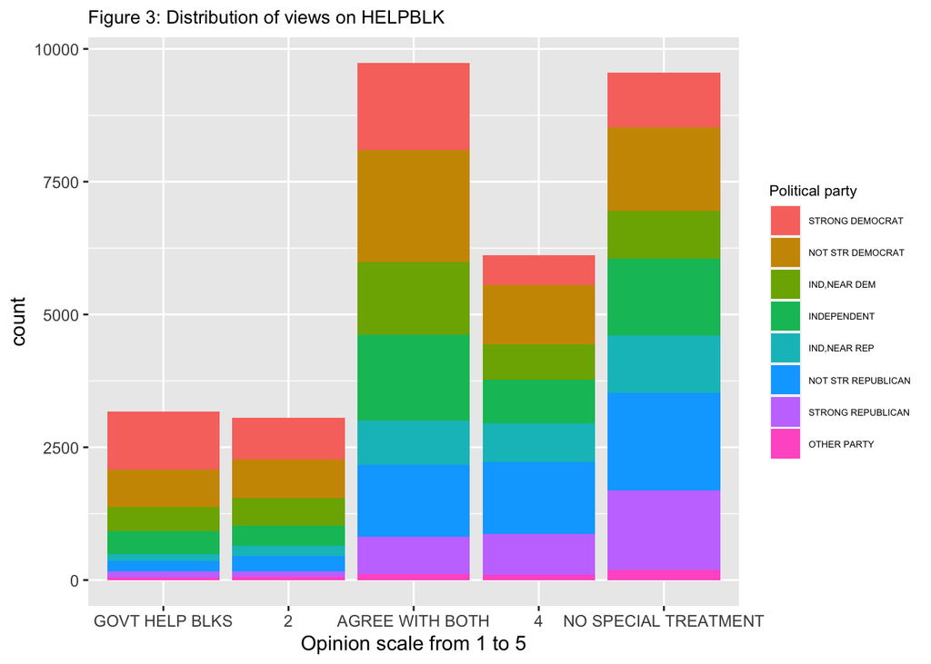

```r
#boxplot 2
ggplot(gss,aes(x=HELPBLK,fill=PARTYID))+geom_bar()+labs(title="Figure 3: Distribution of views on HELPBLK",fill="Political party")+theme(plot.title=element_text(size=10),legend.title=element_text(size=8),legend.text=element_text(size=5))+xlab("Opinion scale from 1 to 5")
```

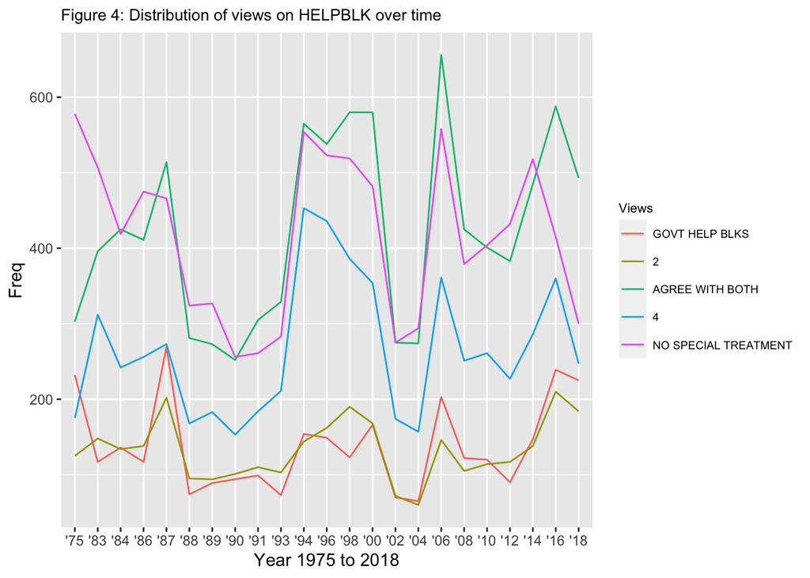

```r
#time-graph 2
helpblkcount_overtime<-as.data.frame(table(YEAR=gss$YEAR,HELPBLK=gss$HELPBLK))

ggplot(helpblkcount_overtime,aes(x=YEAR,y=Freq,group=HELPBLK,color=HELPBLK))+geom_line()+labs(title="Figure 4: Distribution of views on HELPBLK over time",color="Views")+theme(plot.title=element_text(size=10),legend.title=element_text(size=8),legend.text=element_text(size=7))+xlab("Year 1975 to 2018")+scale_x_discrete(labels=c("'75","'83","'84","'86","'87","'88","'89","'90","'91","'93","'94","'96","'98","'00","'02","'04","'06","'08","'10","'12","'14","'16","'18"))
```

**Limitations of MY summary statistics and graphs:** Across these visualisations, only obviously large patterns of differences between variables may I confidently note. I am not able to draw solid insights from smaller and less discernible visual differences (even so, they are on a speculative basis). Furthermore, visualising frequencies, as opposed to proportions, limits my ability to make accurate comparisons between variables. These graphs also do not show me if differences observed are statistically significant.

## Part 4: Inference

I will be using a *chi-square test for a two-way table* to evaluate if my explanatory and response variables are independent from one another - if political party affiliation and views on government obligations and responsibilities (regarding two issues) are independent. If differences between the distribution of variables are statistically significant (<0.05), then there is a high likelihood that the observed relationship is caused by something other than chance - suggesting variables dependency.

**1) Should the government improve standard of living of all poor Americans?**

*Set out hypotheses*

**Null hypothesis:** There is *no difference* in views between people of different political party affiliation on whether or not the government should do everything possible to improve the standard of living of all poor Americans.

**Alternate hypothesis:** There is *some difference* in views.

*Check conditions*

- **Independence:** Independence condition met - random sampling method is used.
- **Sample size/ skew:** Number of sample observation in each level is more than 5.

*Perform inference*

```r
#create dataframe
partyid_helppoor<-as.data.frame.matrix(table(gss$PARTYID,gss$HELPPOOR))%>%rename("govt action"=1,"agree both"=3,"ppl help selves"=5)

#inference test 1
chisq_results1<-chisq.test(partyid_helppoor)
print(chisq_results1)
```

```
##
##  Pearson's Chi-squared test
##
## data:  partyid_helppoor
## X-squared = 3595.4, df = 28, p-value < 2.2e-16
```

```r
#work behind the chi-square test
chisq_results1$observed #calculate observed counts for each level
```

```
##                    govt action   2 agree both    4 ppl help selves
## STRONG DEMOCRAT           1601 872       1977  278             352
## NOT STR DEMOCRAT          1172 992       2956  658             466
## IND,NEAR DEM               725 683       1872  381             260
## INDEPENDENT                904 505       2304  504             476
## IND,NEAR REP               280 323       1266  634             457
## NOT STR REPUBLICAN         442 467       2244 1180             685
## STRONG REPUBLICAN          236 180       1171  824             786
## OTHER PARTY                 82  57        197   90              85
```

```r
chisq_results1$expected #calculate expected counts for each level
```

```
##                    govt action         2 agree both         4 ppl help selves
## STRONG DEMOCRAT      874.18922 655.24032  2246.8366 730.73994       572.99393
## NOT STR DEMOCRAT    1074.49557 805.37807  2761.6629 898.17721       704.28624
## IND,NEAR DEM         674.74330 505.74750  1734.2217 564.02191       442.26559
## INDEPENDENT          807.59252 605.32339  2075.6701 675.07137       529.34262
## IND,NEAR REP         509.37010 381.79357  1309.1804 425.78548       333.87048
## NOT STR REPUBLICAN   863.51998 647.24330  2219.4146 721.82146       566.00070
## STRONG REPUBLICAN    550.15412 412.36286  1414.0033 459.87709       360.60268
## OTHER PARTY           87.93518  65.91099   226.0105  73.50553        57.63778
```

*Additional: Studying the nature of dependence between the various levels of the variables*

I want to know which cell/ level is contributing most to the total chi-square score. I calculate Pearson residuals (r) for this.

- **Positive residuals** are in blue. These values imply that a positive association exist between the corresponding row and column variables.
- **Negative residuals** are in red. These values imply that a negative association exist between the corresponding variables.

```r
#download package
library(corrplot)

#calculate residuals
chisq_results1$residuals
```

```
##                    govt action          2 agree both          4 ppl help selves
## STRONG DEMOCRAT      24.582080   8.467948 -5.6926578 -16.748171       -9.232203
## NOT STR DEMOCRAT      2.974555   6.576015  3.6980293  -8.014027       -8.978925
## IND,NEAR DEM          1.934749   7.881801  3.3084800  -7.706463       -8.666887
## INDEPENDENT           3.392459  -4.077636  5.0116835  -6.584192       -2.318494
## IND,NEAR REP        -10.162957  -3.008954 -1.1934016  10.090567        6.738654
## NOT STR REPUBLICAN  -14.344386  -7.084763  0.5218658  17.053748        5.001911
## STRONG REPUBLICAN   -13.393700 -11.442659 -6.4622966  16.979587       22.401664
## OTHER PARTY          -0.632925  -1.097607 -1.9297068   1.923881        3.604108
```

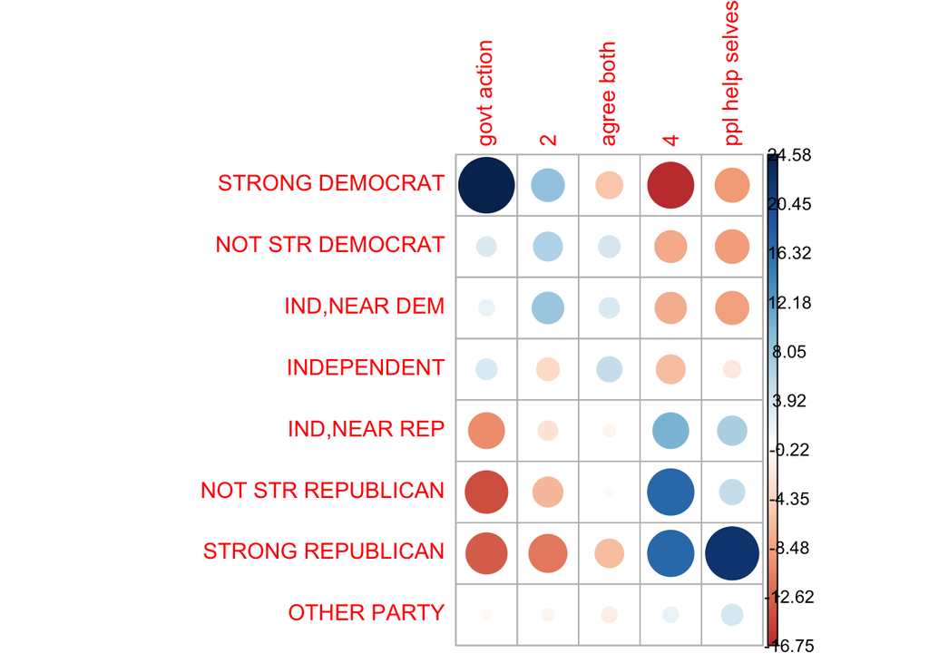

```r
#visualise residuals
corrplot(chisq_results1$residuals,is.cor=FALSE)
```

**2) Should the government provide special treatment to African-Americans?**

*Set out hypotheses*

**Null hypothesis:** There is *no difference* in views between people of different political party affiliation on whether or not the government should be giving special treatment to African-Americans.  
**Alternate hypothesis:** There is *some difference* in views.

*Check conditions*

- **Independence:** Independence condition met - random sampling method is used.
- **Sample size/ skew:** Number of sample observation in each level is more than 5.

*Perform inference*

```r
#create dataframe
partyid_helpblk<-as.data.frame.matrix(table(gss$PARTYID,gss$HELPBLK))%>%rename("govt help blks"=1,"agree both"=3,"no specia treat"=5)

#inference test 2
chisq_results2<-chisq.test(partyid_helpblk)
print(chisq_results2)
```

```
##
##  Pearson's Chi-squared test
##
## data:  partyid_helpblk
## X-squared = 2945.4, df = 28, p-value < 2.2e-16
```

```r
#work behind the chi-square test
chisq_results2$observed #calculate observed counts for each level
```

```
##                    govt help blks   2 agree both    4 no specia treat
## STRONG DEMOCRAT              1094 783       1631  548            1024
## NOT STR DEMOCRAT              708 726       2112 1120            1578
## IND,NEAR DEM                  450 530       1368  676             897
## INDEPENDENT                   435 372       1618  819            1449
## IND,NEAR REP                  123 199        836  724            1078
## NOT STR REPUBLICAN            195 287       1345 1350            1841
## STRONG REPUBLICAN             119 108        703  771            1496
## OTHER PARTY                    49  55        119  102             186
```

```r
chisq_results2$expected #calculate expected counts for each level
```

```
##                    govt help blks         2 agree both          4
## STRONG DEMOCRAT         509.70276 491.55072  1563.3241  981.49507
## NOT STR DEMOCRAT        626.49292 604.18163  1921.5345 1206.38882
## IND,NEAR DEM            393.41427 379.40362  1206.6523  757.56735
## INDEPENDENT             470.87304 454.10385  1444.2283  906.72369
## IND,NEAR REP            296.99216 286.41538   910.9132  571.89476
## NOT STR REPUBLICAN      503.48198 485.55148  1544.2441  969.51619
## STRONG REPUBLICAN       320.77160 309.34796   983.8478  617.68499
## OTHER PARTY              51.27128  49.44536   157.2556   98.72913
##                    no specia treat
## STRONG DEMOCRAT          1533.9274
## NOT STR DEMOCRAT         1885.4021
## IND,NEAR DEM             1183.9625
## INDEPENDENT              1417.0711
## IND,NEAR REP              893.7845
## NOT STR REPUBLICAN       1515.2062
## STRONG REPUBLICAN         965.3476
## OTHER PARTY               154.2986
```

*Additional: Studying the nature of dependence between the various levels of the variables*

```r
#calculate residuals
chisq_results2$residuals
```

```
##                    govt help blks           2 agree both           4
## STRONG DEMOCRAT        25.8806599  13.1455517   1.711630 -13.8369413
## NOT STR DEMOCRAT        3.2563964   4.9559739   4.345024  -2.4872182
## IND,NEAR DEM            2.8528690   7.7315008   4.644850  -2.9635056
## INDEPENDENT            -1.6531652  -3.8528838   4.572578  -2.9132611
## IND,NEAR REP          -10.0961823  -5.1652302  -2.482104   6.3604246
## NOT STR REPUBLICAN    -13.7479464  -9.0106369  -5.070228  12.2196467
## STRONG REPUBLICAN     -11.2658011 -11.4478416  -8.953794   6.1688067
## OTHER PARTY            -0.3172005   0.7899386  -3.050649   0.3291855
##                    no specia treat
## STRONG DEMOCRAT        -13.0198489
## NOT STR DEMOCRAT        -7.0795367
## IND,NEAR DEM            -8.3398094
## INDEPENDENT              0.8481798
## IND,NEAR REP             6.1618319
## NOT STR REPUBLICAN       8.3696422
## STRONG REPUBLICAN       17.0792288
## OTHER PARTY              2.5520984
```

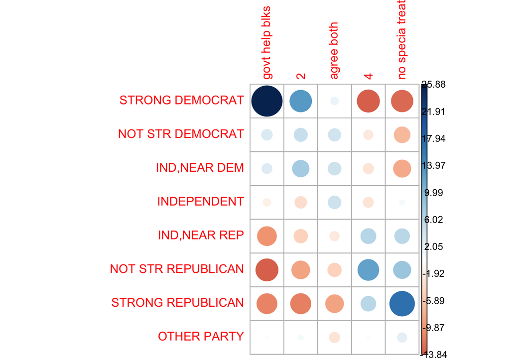

```r
#visualise residuals
corrplot(chisq_results2$residuals,is.cor=FALSE)
```

Ta-da!